# Cardio Good Fitness Project

### The data is about customers of the treadmill product(s) of a retail store called Cardio Good Fitness

```python
# Imports
import pandas as pd
import numpy as np
import seaborn as sns
import matplotlib.pyplot as plt
% matplotlib inline
sns.set(color_codes=True)
```

```python
CardioGoodFitness = pd.read_csv('CardioGoodFitness.csv')
```

```python
CardioGoodFitness.head()
```

|  | Product | Age | Gender | Education | MaritalStatus | Usage | Fitness | Income | Miles |
| --- | --- | --- | --- | --- | --- | --- | --- | --- | --- |
| 0 | TM195 | 18 | Male | 14 | Single | 3 | 4 | 29562 | 112 |
| 1 | TM195 | 19 | Male | 15 | Single | 2 | 3 | 31836 | 75 |
| 2 | TM195 | 19 | Female | 14 | Partnered | 4 | 3 | 30699 | 66 |
| 3 | TM195 | 19 | Male | 12 | Single | 3 | 3 | 32973 | 85 |
| 4 | TM195 | 20 | Male | 13 | Partnered | 4 | 2 | 35247 | 47 |

```python
CardioGoodFitness.shape
```

```
(180, 9)
```

We see from the shape of the dataframe that there are 9 columns / features. There are 6 numerical features and 3 categorical features

## Check for missing values

```python
CardioGoodFitness.isnull().sum()
```

```
Product          0
Age              0
Gender           0
Education        0
MaritalStatus    0
Usage            0
Fitness          0
Income           0
Miles            0
dtype: int64
```

```python
# Analysis of spread and distribution of each numerical feature of the dataset
CardioGoodFitness.describe()
```

|  | Age | Education | Usage | Fitness | Income | Miles |
| --- | --- | --- | --- | --- | --- | --- |
| count | 180.000000 | 180.000000 | 180.000000 | 180.000000 | 180.000000 | 180.000000 |
| mean | 28.788889 | 15.572222 | 3.455556 | 3.311111 | 53719.577778 | 103.194444 |
| std | 6.943498 | 1.617055 | 1.084797 | 0.958869 | 16506.684226 | 51.863605 |
| min | 18.000000 | 12.000000 | 2.000000 | 1.000000 | 29562.000000 | 21.000000 |
| 25% | 24.000000 | 14.000000 | 3.000000 | 3.000000 | 44058.750000 | 66.000000 |
| 50% | 26.000000 | 16.000000 | 3.000000 | 3.000000 | 50596.500000 | 94.000000 |
| 75% | 33.000000 | 16.000000 | 4.000000 | 4.000000 | 58668.000000 | 114.750000 |
| max | 50.000000 | 21.000000 | 7.000000 | 5.000000 | 104581.000000 | 360.000000 |

# Univariate Data Analysis

#### DisPlot and Histograms are types of univariate data analysis

#### Below I will plot for every feature in this dataset

```python
#help(sns.displot)
```

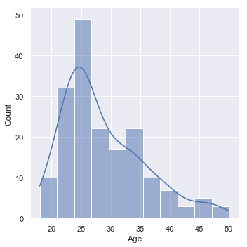

```python
sns.displot(CardioGoodFitness['Age'],kde=True)
```

The above gives a skewed distribution plot which is similar to a normal distribution. We can see that the median Age is around 26. But the mean is towards the right and this distribution is right skewed

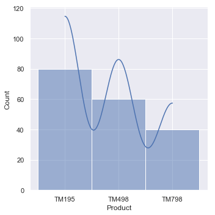

```python
sns.displot(CardioGoodFitness['Product'], kde=True)
```

For product, we see 3 different products. TM195 has the maximum count, and TM798 has the minimum.

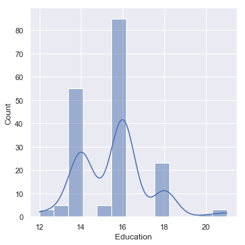

```python
sns.displot(CardioGoodFitness['Education'], kde=True)
```

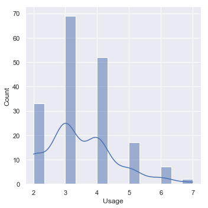

```python
sns.displot(CardioGoodFitness['Usage'], kde=True)
```

The usage has maximum of 7, and minimum of 2. This seems to be the days per week that the customers use this product. Most users use 3 or 4 days

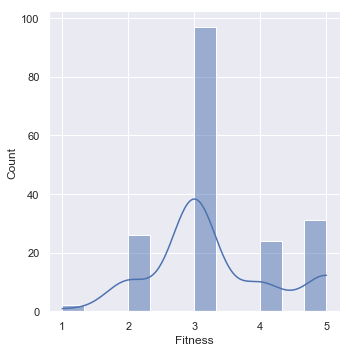

```python
sns.displot(CardioGoodFitness['Fitness'], kde=True)
```

The fitness rating for each user takes discrete values from 1 to 5

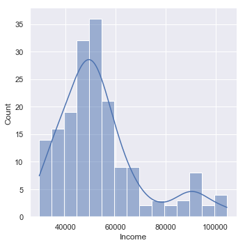

```python
sns.displot(CardioGoodFitness['Income'], kde=True)
```

Income is also positive (right) skewed, as the mean is greater than median.

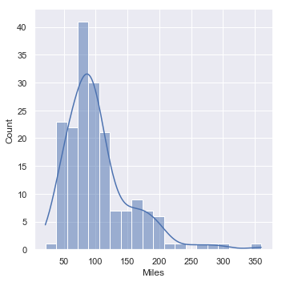

```python
sns.displot(CardioGoodFitness['Miles'], kde=True)
```

Miles is also positively skewed

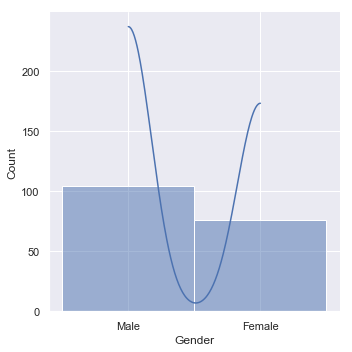

```python
sns.displot(CardioGoodFitness['Gender'], kde=True)
```

The above shows that there are more male users than female users.

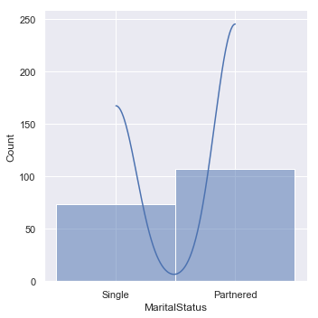

```python
sns.displot(CardioGoodFitness['MaritalStatus'], kde=True)
```

There are more Partnered users than Single users from the sample.

# Multivariate Data Analysis

Multivariate analysis is performed to understand interactions between different fields in the dataset (or) finding interactions between variables more than 2 ex: Pairplot, 3D scatter plot

```python
CardioGoodFitness.describe()
```

|  | Age | Education | Usage | Fitness | Income | Miles |
| --- | --- | --- | --- | --- | --- | --- |
| count | 180.000000 | 180.000000 | 180.000000 | 180.000000 | 180.000000 | 180.000000 |
| mean | 28.788889 | 15.572222 | 3.455556 | 3.311111 | 53719.577778 | 103.194444 |
| std | 6.943498 | 1.617055 | 1.084797 | 0.958869 | 16506.684226 | 51.863605 |
| min | 18.000000 | 12.000000 | 2.000000 | 1.000000 | 29562.000000 | 21.000000 |
| 25% | 24.000000 | 14.000000 | 3.000000 | 3.000000 | 44058.750000 | 66.000000 |
| 50% | 26.000000 | 16.000000 | 3.000000 | 3.000000 | 50596.500000 | 94.000000 |
| 75% | 33.000000 | 16.000000 | 4.000000 | 4.000000 | 58668.000000 | 114.750000 |
| max | 50.000000 | 21.000000 | 7.000000 | 5.000000 | 104581.000000 | 360.000000 |

Above I have described the dataset to determine the types of features. We have 6 numerical features and 3 categorical features - Gender, Product and MaritalStatus

## Numerical vs Numerical Features

## Below we will analyze the 6 numerical features interaction between each other.

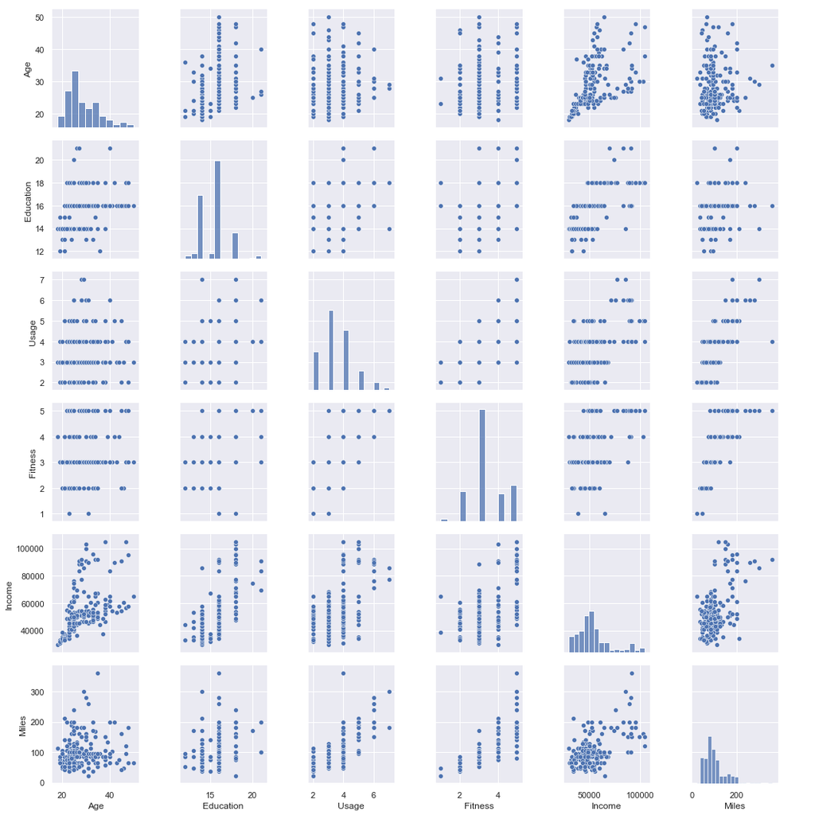

```python
sns.pairplot(CardioGoodFitness)
```

Above is a pairplot of the 6 numerical features.

```python
CardioGoodFitness.corr()
```

|  | Age | Education | Usage | Fitness | Income | Miles |
| --- | --- | --- | --- | --- | --- | --- |
| Age | 1.000000 | 0.280496 | 0.015064 | 0.061105 | 0.513414 | 0.036618 |
| Education | 0.280496 | 1.000000 | 0.395155 | 0.410581 | 0.625827 | 0.307284 |
| Usage | 0.015064 | 0.395155 | 1.000000 | 0.668606 | 0.519537 | 0.759130 |
| Fitness | 0.061105 | 0.410581 | 0.668606 | 1.000000 | 0.535005 | 0.785702 |
| Income | 0.513414 | 0.625827 | 0.519537 | 0.535005 | 1.000000 | 0.543473 |
| Miles | 0.036618 | 0.307284 | 0.759130 | 0.785702 | 0.543473 | 1.000000 |

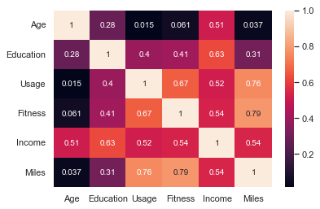

```python
sns.heatmap(CardioGoodFitness.corr(), annot=True)  # plot the correlation coefficients as a heatmap
```

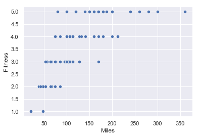

```python
sns.scatterplot(x=CardioGoodFitness['Miles'],y=CardioGoodFitness['Fitness'])
```

## Categorical vs Numerical Features

## Below we will analyze the interaction between 3 categorical features and 6 numerical features.

#### Categorical vs Numerical - Bar chart, Violin Plot, Categorical Box Plot, Swarm plot

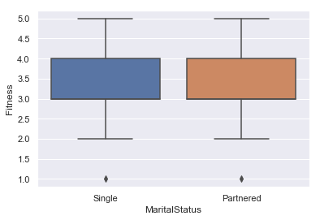

```python
sns.boxplot(x=CardioGoodFitness['MaritalStatus'],y=CardioGoodFitness['Fitness'])
```

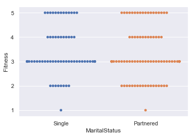

```python
sns.swarmplot(x=CardioGoodFitness['MaritalStatus'],y=CardioGoodFitness['Fitness'])
```

The above 2 plots show that Marital Status of Single or Partnered both have a very similar plot for Fitness.

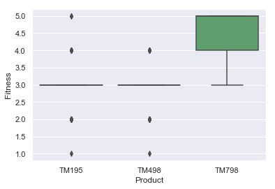

```python
sns.boxplot(x=CardioGoodFitness['Product'],y=CardioGoodFitness['Fitness'])
```

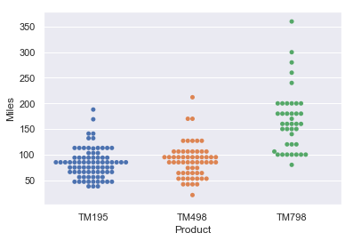

```python
sns.swarmplot(data=CardioGoodFitness,x='Product',y='Miles')
```

The above swarmplot shows how people using TM798 have much higher number of miles on their treadmill. TM498 has slightly more than TM195, but the two are very close in terms of miles.

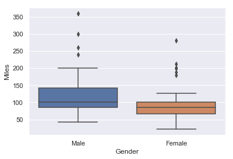

```python
sns.boxplot(x=CardioGoodFitness['Gender'],y=CardioGoodFitness['Miles'])
```

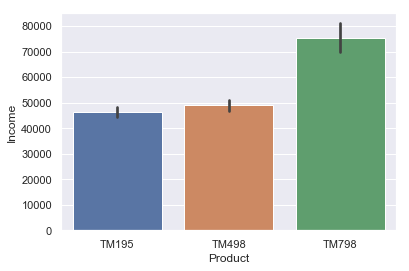

```python
sns.barplot(x='Product',y='Income',data=CardioGoodFitness)
```

The above bar plot shows that people with higher income prefer to buy TM798. The incomes of people buying TM195 and TM498 is similar.

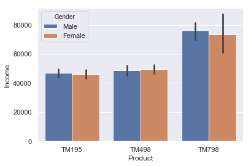

```python
sns.barplot(x='Product',y='Income',data=CardioGoodFitness, hue = 'Gender')
```

We can also plot the bar plot of income vs product and use gender as hue to indicate difference in income between gender. We see that males buying TM798 have slightly higher income, while TM195 and TM498 have incomes very close for both genders.

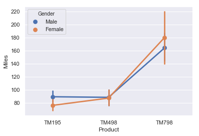

```python
sns.pointplot(data=CardioGoodFitness,x='Product',y='Miles',hue='Gender')
```

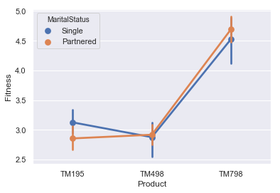

```python
sns.pointplot(data=CardioGoodFitness,x='Product',y='Fitness',hue='MaritalStatus')
```

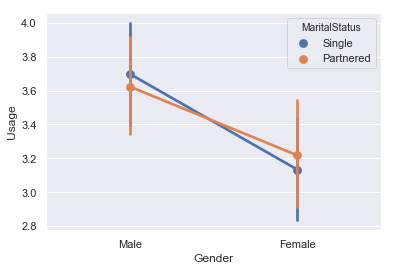

```python
sns.pointplot(data=CardioGoodFitness,x='Gender',y='Usage',hue='MaritalStatus')
```

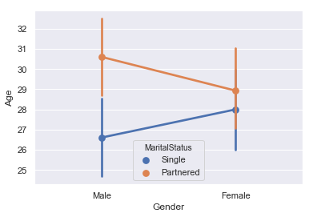

```python
sns.pointplot(data=CardioGoodFitness,x='Gender',y='Age',hue='MaritalStatus')
```

#### We can also do countplots for the 3 categorical variables among each other.

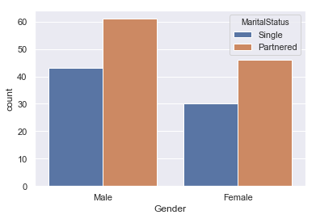

```python
sns.countplot(data=CardioGoodFitness,x='Gender',hue='MaritalStatus')
```

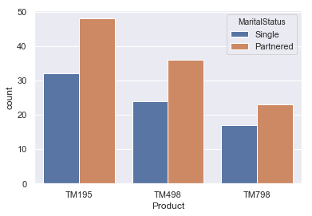

```python
sns.countplot(data=CardioGoodFitness,x='Product',hue='MaritalStatus')
```

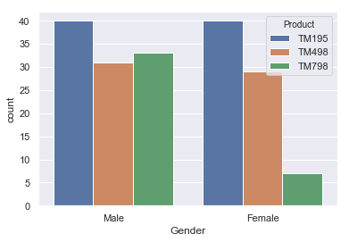

```python
sns.countplot(data=CardioGoodFitness,x='Gender',hue='Product')
```

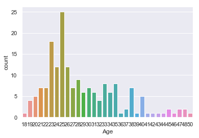

```python
sns.countplot(data=CardioGoodFitness,x='Age')
```

# Conclusion and Recommendations

1) Product - It looks like TM798 is sold more to higher income people, and there are very few women that have bought it. This can be advertised better to women. Also, as the people that use this product do a lot more miles, it could be worth checking to see if price for this can be reduced a bit, so that more people can buy this product and have better miles and fitness, as those are positively correlated.

2) From the correlation heatmap of six numerical variables, it shows that Fitness-Miles, Miles-Usage have high positive correlation > 0.75. This can be positively represented to general population, that people who use the Cardio Good Fitness treadmills more are more fit. Fitness-Usage also has a positive correlation 0.67. Usage-Income also has positive correlation of 0.52. However there could be a scope of reducing price, or creating a fourth treadmill product to cater to lower-income people.

3) Gender - From the countplot of gender, we see single females are the lowest buyers. The product can be advertised better to them, or made in different colors, to be attractive for them to buy.

4) Age - From the countplot of age, we see that more users for this treadmill are between age 23-28. There are some users in 30's but a lot less in 40's. There could be some sales targeted to show how people above 40 could also use this product and be more fit.